# Searching Genes and Proteins for Domains and Motifs

Cenk Celik

05/11/2020

The sequences of genes, proteins, and entire genomes hold clues to their function. Repeated subsequences or sequences with a strong similarity to each other can be clues to things such as evolutionary conservation or functional relatedness. As such, sequence analysis for motifs and domains are core techniques in bioinformatics. Bioconductor contains many useful packages for analyzing genes, proteins, and genomes. Here, I will use Bioconductor to analyse sequences for features of functional interest, such as *de novo* DNA motifs and known domains from widely used databases.

Outline:

- Finding DNA motifs
- Finding protein domains
- Performing multiple alignments
- Aligning genomic length sequences
- Machine learning for novel feature detection
- 3D structure protein alignment

I will also need MEME, a program for finding statistically overrepresented sequence motifs in sets of sequences. You can download the software from http://meme-suite.org/doc/download.html/, then type the following commands

> tar zxf meme-5.x.x.tar.gz cd meme-5.x.x ./configure –prefix=$HOME/meme –with-url=http://alternate.meme-suite.org/ –enable-build-libxml2 –enable-build-libxslt make make test make install

Edit your shell configuration file to add $HOME/meme/bin and $HOME/meme/libexec/meme-5.x.x to your shell’s path. This can often be done by editing the file named .profile to add the following line:

> export PATH=$HOME/meme/bin:$HOME/meme/libexec/meme-5.x.x:$PATH

## Finding DNA motifs

Load libraries:

```r
library(universalmotif)
library(Biostrings)
```

Load a motif of interest:

```r
motif <- read_matrix(file.path(getwd(), "simple_motif.txt"))
```

Load sequences to scan with the motif:

```r
sequences <- readDNAStringSet(file.path(getwd(), "promoters.fa"))
```

Perform a scan:

```r
motif_hits <- scan_sequences(motif, sequences = sequences)
motif_hits
```

```
## DataFrame with 616 rows and 12 columns
##               motif   motif.i    sequence     start      stop     score
##         <character> <integer> <character> <integer> <integer> <numeric>
## 1   YTTTYTTTTTYTTTY         1   AT4G28150        73        87     7.884
## 2   YTTTYTTTTTYTTTY         1   AT4G28150        75        89    10.986
## 3   YTTTYTTTTTYTTTY         1   AT4G28150        76        90     6.322
## 4   YTTTYTTTTTYTTTY         1   AT4G28150        77        91    13.184
## 5   YTTTYTTTTTYTTTY         1   AT4G28150        79        93     4.017
## ...             ...       ...         ...       ...       ...       ...
## 612 YTTTYTTTTTYTTTY         1   AT3G19200       238       252     5.026
## 613 YTTTYTTTTTYTTTY         1   AT3G19200       241       255     5.501
## 614 YTTTYTTTTTYTTTY         1   AT3G19200       243       257     4.146
## 615 YTTTYTTTTTYTTTY         1   AT3G19200       658       672     5.549
## 616 YTTTYTTTTTYTTTY         1   AT3G19200       659       673     3.800
##               match thresh.score min.score max.score score.pct      strand
##         <character>    <numeric> <numeric> <numeric> <numeric> <character>
## 1   ATTTCTTTTACTTTC       3.2753   -91.208    22.423   35.1603           +
## 2   TTCTTTTACTTTCTC       3.2753   -91.208    22.423   48.9943           +
## 3   TCTTTTACTTTCTCT       3.2753   -91.208    22.423   28.1943           +
## 4   CTTTTACTTTCTCTT       3.2753   -91.208    22.423   58.7968           +
## 5   TTTACTTTCTCTTTA       3.2753   -91.208    22.423   17.9146           +
## ...             ...          ...       ...       ...       ...         ...
## 612 CCATTTTTTTTGTTC       3.2753   -91.208    22.423   22.4145           +
## 613 TTTTTTTTGTTCACC       3.2753   -91.208    22.423   24.5328           +
## 614 TTTTTTGTTCACCCT       3.2753   -91.208    22.423   18.4899           +
## 615 TGTTATTTTTTTGTT       3.2753   -91.208    22.423   24.7469           +
## 616 GTTATTTTTTTGTTG       3.2753   -91.208    22.423   16.9469           +
```

Calculate if the motif is enriched in the sequences:

```r
motif_info <- enrich_motifs(motif,
                            sequences,
                            shuffle.k = 3,
                            verbose = 0,
                            RC = TRUE)
motif_info
```

```
## DataFrame with 1 row and 11 columns
##             motif   motif.i target.hits target.seq.hits target.seq.count
##       <character> <integer>   <integer>       <integer>        <integer>
## 1 YTTTYTTTTTYTTTY         1        1287              50               50
##    bkg.hits bkg.seq.hits bkg.seq.count        Pval        Qval        Eval
##   <integer>    <integer>     <integer>   <numeric>   <numeric>   <numeric>
## 1       664           49            50 1.57227e-46 1.57227e-46 3.14454e-46
```

Run MEME to find novel motifs:

```r
meme_path = "/Users/cenkcelik/meme/bin/meme"
meme_run <- run_meme(sequences,
                     bin = meme_path,
                     output = "meme_out",
                     overwrite.dir = TRUE)
```

```
## Using MEME version 5.2.0
```

```
## Output folder: meme_out
```

```
## NOTE: output folder already exists, will be overwritten
```

```
## Search mode: Classic
```

```
## Model: Zero or One Occurrence Per Sequence
```

```
## Looking for 3 motifs
```

```
##
##  *** Starting MEME ***
##
## [ Thu Nov  5 23:46:41 2020 ]
```

```
## Running /Users/cenkcelik/meme/bin/meme \
##   /Users/cenkcelik/Projects/r_bioinformatics_cookbook/3.searching_genes/target.temp.fasta \
##   -oc meme_out -dna -shuf 2 -objfun classic -mod zoops -minw 8 -maxw 50 -wg \
##   11 -ws 1 -markov_order 0 -maxiter 50 -distance 0.001 -brief 1000 -shuf 2 \
##   -csites 1000 -nmotifs 3 -seed 0 -wnsites 0.8
```

```
## [ Thu Nov  5 23:46:41 2020 ]
```

```
## Generating motif 1
```

```
## [ Thu Nov  5 23:47:52 2020 ]
```

```
## Generating motif 2
```

```
## [ Thu Nov  5 23:49:06 2020 ]
```

```
## Generating motif 3
```

```
## [ Thu Nov  5 23:50:10 2020 ]
##
##  *** Run over ***
##
## Total runtime: 3.487613 mins
```

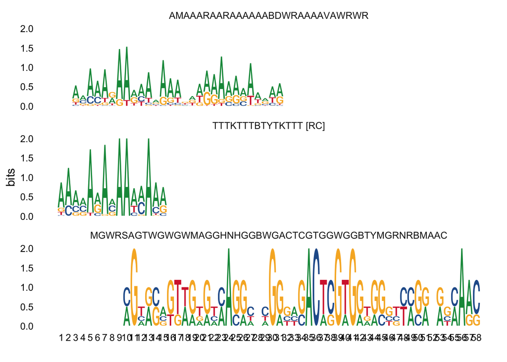

```r
motifs <- read_meme("meme_out/meme.txt")
view_motifs(motifs)
```

## Finding protein domains

Next step is to discover the function of a protein sequence. Here, I will use *PFAM* database that encodes protein domains as profile Hidden Markov Models and reports any likely occurrences of domains.

I will need *Annotationdbi* database package, more specifically *org.Gs.eg.db*, *org.EcK12.eg.db* and *org.At.tair.db*. Also, I will need *bio3d* package.

Load the database package and inspect the types of keys in the database:

```r
library(org.Hs.eg.db)
keytypes(org.Hs.eg.db)
```

```
##  [1] "ACCNUM"       "ALIAS"        "ENSEMBL"      "ENSEMBLPROT"  "ENSEMBLTRANS"
##  [6] "ENTREZID"     "ENZYME"       "EVIDENCE"     "EVIDENCEALL"  "GENENAME"
## [11] "GO"           "GOALL"        "IPI"          "MAP"          "OMIM"
## [16] "ONTOLOGY"     "ONTOLOGYALL"  "PATH"         "PFAM"         "PMID"
## [21] "PROSITE"      "REFSEQ"       "SYMBOL"       "UCSCKG"       "UNIGENE"
## [26] "UNIPROT"
```

Now, get a vector of keys and query the database:

```r
k <- head(keys(org.Hs.eg.db,
               keytype = "ENSEMBL"), n = 3)

result <- select(org.Hs.eg.db,
                 keys = k,
                 keytype = "ENSEMBL",
                 columns = c("PFAM"))
result
```

```
##           ENSEMBL    PFAM
## 1 ENSG00000121410 PF13895
## 2 ENSG00000175899 PF17789
## 3 ENSG00000175899 PF01835
## 4 ENSG00000175899 PF07703
## 5 ENSG00000175899 PF17791
## 6 ENSG00000175899 PF07678
## 7 ENSG00000175899 PF07677
## 8 ENSG00000175899 PF00207
## 9 ENSG00000256069    <NA>
```

Load the *PFAM* database and extract descriptions, then get all keys from the *PFAM* database:

```r
library(PFAM.db)
```

```r
descriptions <- PFAMDE

all_ids <- mappedkeys(descriptions)
id_description_mapping <- as.data.frame(descriptions[all_ids])
```

Join the descriptions to *PFAM*:

```r
library(dplyr)
left_join(result,
          id_description_mapping,
          by = c("PFAM" = "ac"))
```

```
##           ENSEMBL    PFAM                                       de
## 1 ENSG00000121410 PF13895                    Immunoglobulin domain
## 2 ENSG00000175899 PF17789                 Macroglobulin domain MG4
## 3 ENSG00000175899 PF01835                               MG2 domain
## 4 ENSG00000175899 PF07703 Alpha-2-macroglobulin bait region domain
## 5 ENSG00000175899 PF17791                 Macroglobulin domain MG3
## 6 ENSG00000175899 PF07678               A-macroglobulin TED domain
## 7 ENSG00000175899 PF07677  A-macroglobulin receptor binding domain
## 8 ENSG00000175899 PF00207             Alpha-2-macroglobulin family
## 9 ENSG00000256069    <NA>                                     <NA>
```

## Finding InterPro domains

InterPro -a database of predictive models- aggregates information from multiple sources to reduce redundancy in annotations and aid interpretability.

Load the libraries and check if the database has the protein data of interest:

```r
library(ensembldb)
library(EnsDb.Rnorvegicus.v79)
hasProteinData(EnsDb.Rnorvegicus.v79)
```

```
## [1] TRUE
```

Build a list of genes to query:

```r
e <- EnsDb.Rnorvegicus.v79
k <- head(keys(e, keytype = "GENEID"), n = 3)
```

Pull relevant data:

```r
select(e,
       keys = GeneIdFilter(k),
       columns = c("TXBIOTYPE",
                   "UNIPROTID",
                   "PROTEINID",
                   "INTERPROACCESSION"))
```

```
##         TXBIOTYPE UNIPROTID          PROTEINID INTERPROACCESSION
## 1  protein_coding    Q32KJ7 ENSRNOP00000052495         IPR017850
## 2  protein_coding    Q32KJ7 ENSRNOP00000052495         IPR000917
## 3  protein_coding    C9E895 ENSRNOP00000000008         IPR015424
## 4  protein_coding    B3VQJ0 ENSRNOP00000000008         IPR015424
## 5  protein_coding    P18088 ENSRNOP00000000008         IPR015424
## 6  protein_coding    C9E895 ENSRNOP00000000008         IPR002129
## 7  protein_coding    B3VQJ0 ENSRNOP00000000008         IPR002129
## 8  protein_coding    P18088 ENSRNOP00000000008         IPR002129
## 9  protein_coding    C9E895 ENSRNOP00000000008         IPR001597
## 10 protein_coding    B3VQJ0 ENSRNOP00000000008         IPR001597
## 11 protein_coding    P18088 ENSRNOP00000000008         IPR001597
## 12 protein_coding    C9E895 ENSRNOP00000000008         IPR000192
## 13 protein_coding    B3VQJ0 ENSRNOP00000000008         IPR000192
## 14 protein_coding    P18088 ENSRNOP00000000008         IPR000192
```

[output cut: 23 more lines]

For non-ENSEMBL databases, I will use *biomaRt* package.

```r
library(biomaRt)
biomart_athal <- useMart(biomart = "plants_mart",
                         host = "plants.ensembl.org",
                         dataset = "athaliana_eg_gene")

getBM(c("tair_locus", "interpro"),
      filters = c("tair_locus"),
      values = c("AT5G40950", "AT2G40510"),
      biomart_athal)
```

```
##   tair_locus  interpro
## 1  AT2G40510 IPR000892
## 2  AT2G40510 IPR038551
## 3  AT5G40950 IPR001684
## 4  AT5G40950 IPR018261
```

## Performing multiple alignments of genes or proteins

I will use *ape* and *DECIPHER* packages to determine conserved and divergent regions of aligned sequences.

I will need *msa*, *ape* and *seqinR* packages.

Load the libraries and sequences:

```r
library(msa)
seqs <- readAAStringSet(file.path(getwd(), "hglobin.fa"))
```

Perform multiple sequence alignment:

```r
alignment <- msa(seqs, method = "ClustalOmega")
```

```
## using Gonnet
```

```r
alignment
```

```
## ClustalOmega 1.2.0
##
## Call:
##    msa(seqs, method = "ClustalOmega")
##
## MsaAAMultipleAlignment with 3 rows and 142 columns
##     aln                                                    names
## [1] MVLSPADKTNVKAAWGKVGAHAGEYG...FTPAVHASLDKFLASVSTVLTSKYR HBA_HUMAN
## [2] MVLSGEDKSNIKAAWGKIGGHGAEYG...FTPAVHASLDKFLASVSTVLTSKYR HBA_MOUSE
## [3] MSLTRTERTIILSLWSKISTQADVIG...FTADAHAAWDKFLSIVSGVLTEKYR HBAZ_CAPHI
## Con MVLS??DKTNIKAAWGKIG?HA?EYG...FTPAVHASLDKFLASVSTVLTSKYR Consensus
```

Visualise the result:

```r
msaPrettyPrint(alignment,
               output = "pdf",
               showNames = "left",
               showLogo = "top",
               askForOverwrite = FALSE,
               verbose = FALSE,
               file = "whole_aligned.pdf")
```

Tree visualisation:

```r
library(ape)
library(seqinr)
```

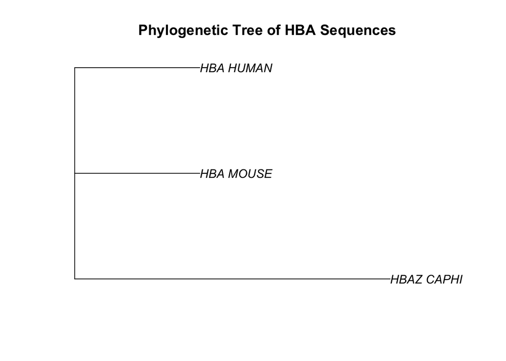

```r
alignment_seqinr <- msaConvert(alignment,
                               type = "seqinr::alignment")
distances <- dist.alignment(alignment_seqinr,
                            "identity")
tree <- nj(distances)
plot(tree, main = "Phylogenetic Tree of HBA Sequences")
```

## Aligning genomic length sequences

For longer sequences, it is harder than aligning shorter sequences. It all starts with finding short anchor alignments and working the alignment out from there. The process usually ends up with blocks of synteny: regions that match well between the different genome alignments.

I will need *DECIPHER* package.

Load the libraries and genome sequences:

```r
library(DECIPHER)
long_seqs <- readDNAStringSet(file.path(getwd(), "plastid_genomes.fa"))
long_seqs
```

```
## DNAStringSet object of length 5:
##      width seq                                              names
## [1] 130584 GGCATAAGCTATCTTCCCAAAGG...ATGATTCAAACATAAAAGTCCT NC_018523.1 Sacch...
## [2] 161592 ATGGGCGAACGACGGGAATTGAA...AAAGAAAAAAAAATAGGAGTAA NC_022431.1 Ascle...
## [3] 117672 ATGAGTACAACTCGAAAGTCCAC...TTGATTTCATCCACAAACGAAC NC_022259.1 Nanno...
## [4] 154731 TTATCCATTTGTAGATGGAACTT...CATATACACTAAGACAAAAGTC NC_022417.1 Cocos...
## [5] 156618 GGGCGAACGACGGGAATTGAACC...CCTTTTGTAGCGAATCCGTTAT NC_022459.1 Camel...
```

Prepare the sequences in a local database:

```r
Seqs2DB(long_seqs,
        "XStringSet",
        "long_db",
        names(long_seqs))
```

```
## Adding 5 sequences to the database.
##
## Added 5 new sequences to table Seqs.
## 15 total sequences in table Seqs.
## Time difference of 0.25 secs
```

Find the blocks of synteny:

```r
synteny <- FindSynteny("long_db")
```

```
## ================================================================================
##
## Time difference of 6.64 secs
```

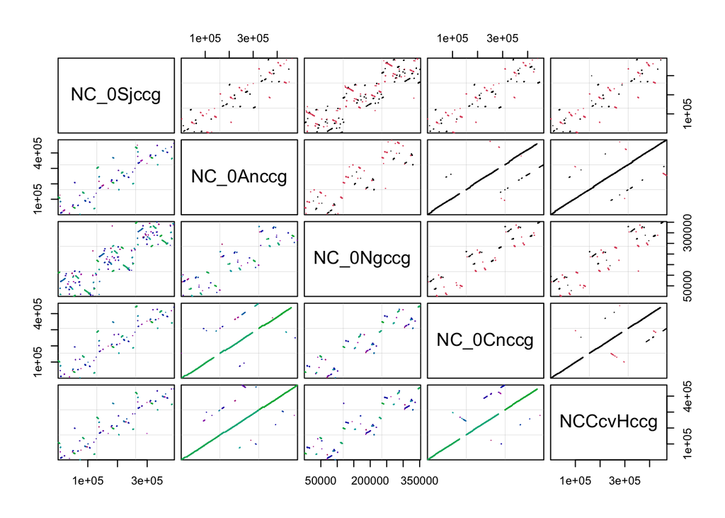

```r
pairs(synteny)
```

Plot the synteny blocks:

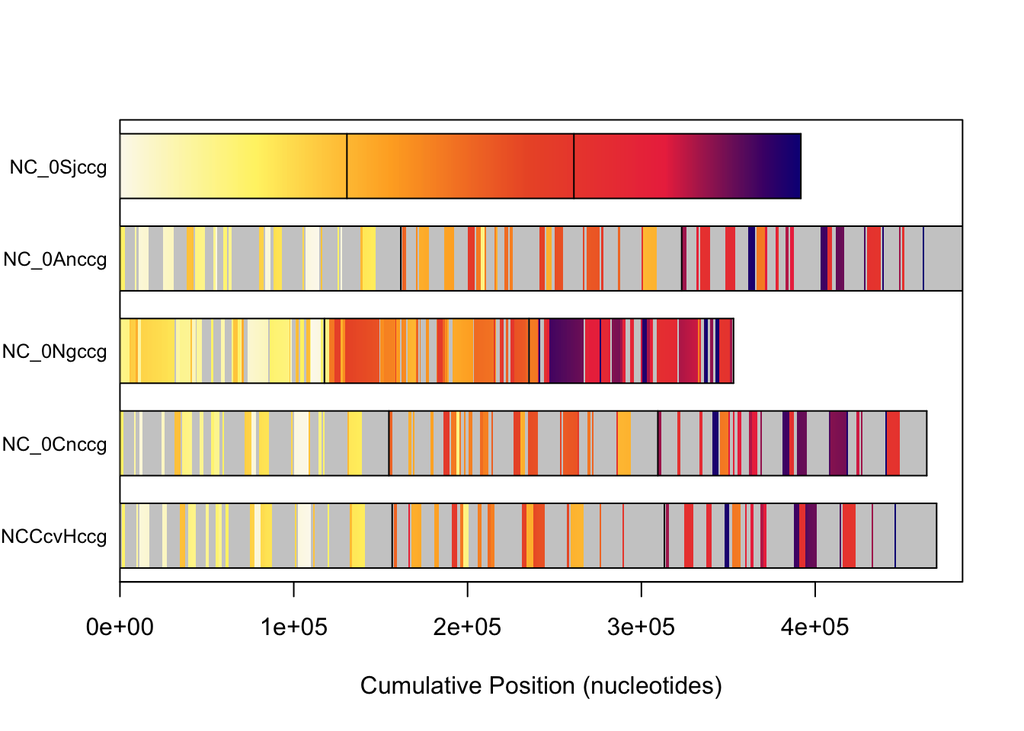

```r
plot(synteny)
```

Make an alignment:

```r
alignment <- AlignSynteny(synteny, "long_db")
```

```
## ================================================================================
##
## Time difference of 42.75 secs
```

```r
blocks <- unlist(alignment[[1]])
writeXStringSet(blocks, "genome_blocks_out.fa")
```

## Machine learning for novel feature detection in proteins

Here, I will build a machine learning model that can classify protein of interest accurately. This model will then be used to show which parts of the proteins result in the classification.

I will need *kebabs*, *Biostrings*, *e1071*, and *readr* libraries.

Load the libraries and input files:

```r
library(kebabs)
library(Biostrings)
library(readr)

seqs <- readAAStringSet(file.path(getwd(), "ecoli_proteins.fa"))
classes <- read_csv(file.path(getwd(), "ecoli_protein_classes.txt"), col_names = TRUE)
classes <- classes$class
```

Separate training and test sets:

```r
num_seqs <- length(seqs)
training_proportion <- 0.75
training_set_indices <- sample(1:num_seqs,
                               training_proportion * num_seqs)
test_set_indices <- c(1:num_seqs)[-training_set_indices]
```

Build the model with training dataset:

```r
kernel <- gappyPairKernel(k = 1, m = 3)
model <- kbsvm(x = seqs[training_set_indices],
               y = classes[training_set_indices],
               kernel = kernel,
               pkg = "e1071",
               svm = "C-svc",
               cost = 15)
```

Use the model to predict the classes of the test dataset:

```r
predictions <- predict(model,
                       seqs[test_set_indices])

evaluatePrediction(predictions,
                   classes[test_set_indices],
                   allLabels = c(1, -1))
```

```
##     1 -1
## 1  34 21
## -1  8 25
##
## Accuracy:              67.045% (59 of 88)
## Balanced accuracy:     67.650% (34 of 42 and 25 of 46)
## Matthews CC:            0.364
##
## Sensitivity:           80.952% (34 of 42)
## Specificity:           54.348% (25 of 46)
## Precision:             61.818% (34 of 55)
```

Examine the prediction profile of a sequence, then plot prediction profile:

```r
seq_to_test <- seqs[[1]][1:10]
seq_to_test
```

```
## 10-letter AAString object
## seq: MSFDIAKYPT
```

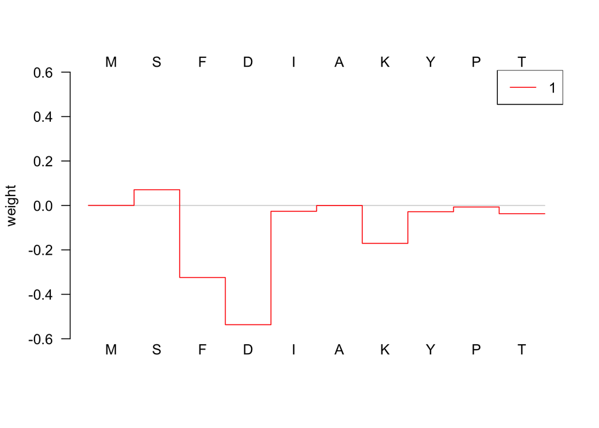

```r
prediction_profile <- getPredictionProfile(seq_to_test,
                                           kernel,
                                           featureWeights(model),
                                           modelOffset(model))

plot(prediction_profile)
```

## 3D structure protein alignment

3D models can reveal structural properties that are common or unique to proteins: these can suggest evolutionary or functional commonalities.

I will use *bio3d* package.

Load the library and PDB structure files:

```r
library(bio3d)
a <- read.pdb(file.path(getwd(), "1xwc.pdb"))
b <- read.pdb(file.path(getwd(), "3trx.pdb"))
```

Align the structure:

```r
pdbs <- pdbaln(list("1xwc" = a,
                    "3trx" = b),
               fit = TRUE,
               exefile = "msa")
```

```
##
##
## Extracting sequences
##
## pdb/seq: 1   name: seq1
## pdb/seq: 2   name: seq2
```

Launch and render the alignment in PyMOL:

```r
pymol(pdbs,
      exefile = "/usr/local/bin/pymol",
      type = "launch",
      as = "cartoon")
```

Output:

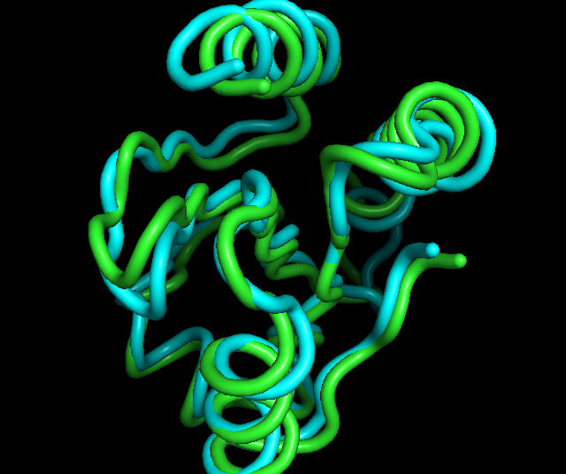